## The dataset is from an ongoing cardiovascular study on residents of the town of Framingham, Massachusetts. The classification goal is to predict whether the patient has a 10-year risk of future coronary heart disease (CHD). The dataset provides the patients’ information. It includes over 3390 records and 15 attributes.

# **Variables**

Each attribute is a potential risk factor. There are both demographic behavioral, and medical risk factors.

# **Data Description**

Demographic:

- Sex: male or female("M" or "F")
- Age: Age of the patient;(Continuous - Although the recorded ages have been truncated to whole numbers, the concept of age is continuous) Behavioral
- Is_smoking: whether or not the patient is a current smoker ("YES" or "NO")
- Cigs Per Day: the number of cigarettes that the person smoked on average in one day.(can be considered continuous as one can have any number of cigarettes, even half a cigarette.) Medical( history)
- BP Meds: whether or not the patient was on blood pressure medication (Nominal)
- Prevalent Stroke: whether or not the patient had previously had a stroke (Nominal)
- Prevalent Hyp: whether or not the patient was hypertensive (Nominal)
- Diabetes: whether or not the patient had diabetes (Nominal) Medical(current)
- Tot Chol: total cholesterol level (Continuous)
- Sys BP: systolic blood pressure (Continuous)
- Dia BP: diastolic blood pressure (Continuous)
- BMI: Body Mass Index (Continuous)
- Heart Rate: heart rate (Continuous - In medical research, variables such as heart rate though in fact discrete, yet are considered continuous because of large number of possible values.)
- Glucose: glucose level (Continuous) Predict variable (desired target)
- **10-year risk of coronary heart disease CHD(binary: “1”, means “Yes”, “0” means “No”) - DV**

# **Loading and Exploring Data**

```python
import pandas as pd
import numpy as np
import matplotlib.pyplot as plt
plt.style.use('ggplot')
import seaborn as sns
import warnings
warnings.filterwarnings('ignore')

from sklearn.preprocessing import LabelEncoder
from sklearn.tree import DecisionTreeClassifier, export_graphviz
from sklearn import tree
from IPython.display import SVG
from graphviz import Source
from IPython.display import display
from sklearn.ensemble import RandomForestClassifier
from sklearn.ensemble import GradientBoostingClassifier
from sklearn.model_selection import GridSearchCV
from sklearn.metrics import roc_auc_score, confusion_matrix, accuracy_score, roc_curve
from sklearn.neighbors import KNeighborsClassifier
from sklearn.svm import SVC
```

```python
df=pd.read_csv('train.csv')
```

```python
df.head()
```

|  | id | age | education | sex | is_smoking | cigsPerDay | BPMeds | prevalentStroke | prevalentHyp | diabetes | totChol | sysBP | diaBP | BMI | heartRate | glucose | TenYearCHD |
| --- | --- | --- | --- | --- | --- | --- | --- | --- | --- | --- | --- | --- | --- | --- | --- | --- | --- |
| 0 | 0 | 64 | 2.0 | F | YES | 3.0 | 0.0 | 0 | 0 | 0 | 221.0 | 148.0 | 85.0 | NaN | 90.0 | 80.0 | 1 |
| 1 | 1 | 36 | 4.0 | M | NO | 0.0 | 0.0 | 0 | 1 | 0 | 212.0 | 168.0 | 98.0 | 29.77 | 72.0 | 75.0 | 0 |
| 2 | 2 | 46 | 1.0 | F | YES | 10.0 | 0.0 | 0 | 0 | 0 | 250.0 | 116.0 | 71.0 | 20.35 | 88.0 | 94.0 | 0 |
| 3 | 3 | 50 | 1.0 | M | YES | 20.0 | 0.0 | 0 | 1 | 0 | 233.0 | 158.0 | 88.0 | 28.26 | 68.0 | 94.0 | 1 |
| 4 | 4 | 64 | 1.0 | F | YES | 30.0 | 0.0 | 0 | 0 | 0 | 241.0 | 136.5 | 85.0 | 26.42 | 70.0 | 77.0 | 0 |

```python
df.tail()
```

|  | id | age | education | sex | is_smoking | cigsPerDay | BPMeds | prevalentStroke | prevalentHyp | diabetes | totChol | sysBP | diaBP | BMI | heartRate | glucose | TenYearCHD |
| --- | --- | --- | --- | --- | --- | --- | --- | --- | --- | --- | --- | --- | --- | --- | --- | --- | --- |
| 3385 | 3385 | 60 | 1.0 | F | NO | 0.0 | 0.0 | 0 | 0 | 0 | 261.0 | 123.5 | 79.0 | 29.28 | 70.0 | 103.0 | 0 |
| 3386 | 3386 | 46 | 1.0 | F | NO | 0.0 | 0.0 | 0 | 0 | 0 | 199.0 | 102.0 | 56.0 | 21.96 | 80.0 | 84.0 | 0 |
| 3387 | 3387 | 44 | 3.0 | M | YES | 3.0 | 0.0 | 0 | 1 | 0 | 352.0 | 164.0 | 119.0 | 28.92 | 73.0 | 72.0 | 1 |
| 3388 | 3388 | 60 | 1.0 | M | NO | 0.0 | NaN | 0 | 1 | 0 | 191.0 | 167.0 | 105.0 | 23.01 | 80.0 | 85.0 | 0 |
| 3389 | 3389 | 54 | 3.0 | F | NO | 0.0 | 0.0 | 0 | 0 | 0 | 288.0 | 124.0 | 77.0 | 29.88 | 79.0 | 92.0 | 0 |

```python
df.shape
```

```
(3390, 17)
```

```python
df.info()
```

```
<class 'pandas.core.frame.DataFrame'>
RangeIndex: 3390 entries, 0 to 3389
Data columns (total 17 columns):
 #   Column           Non-Null Count  Dtype
---  ------           --------------  -----
 0   id               3390 non-null   int64
 1   age              3390 non-null   int64
 2   education        3303 non-null   float64
 3   sex              3390 non-null   object
 4   is_smoking       3390 non-null   object
 5   cigsPerDay       3368 non-null   float64
 6   BPMeds           3346 non-null   float64
 7   prevalentStroke  3390 non-null   int64
 8   prevalentHyp     3390 non-null   int64
 9   diabetes         3390 non-null   int64
 10  totChol          3352 non-null   float64
 11  sysBP            3390 non-null   float64
 12  diaBP            3390 non-null   float64
 13  BMI              3376 non-null   float64
 14  heartRate        3389 non-null   float64
 15  glucose          3086 non-null   float64
 16  TenYearCHD       3390 non-null   int64
dtypes: float64(9), int64(6), object(2)
memory usage: 450.4+ KB
```

```python
df.describe(include='all').T
```

|  | count | unique | top | freq | mean | std | min | 25% | 50% | 75% | max |
| --- | --- | --- | --- | --- | --- | --- | --- | --- | --- | --- | --- |
| id | 3390.0 | NaN | NaN | NaN | 1694.5 | 978.753033 | 0.0 | 847.25 | 1694.5 | 2541.75 | 3389.0 |
| age | 3390.0 | NaN | NaN | NaN | 49.542183 | 8.592878 | 32.0 | 42.0 | 49.0 | 56.0 | 70.0 |
| education | 3303.0 | NaN | NaN | NaN | 1.970936 | 1.019081 | 1.0 | 1.0 | 2.0 | 3.0 | 4.0 |
| sex | 3390 | 2 | F | 1923 | NaN | NaN | NaN | NaN | NaN | NaN | NaN |
| is_smoking | 3390 | 2 | NO | 1703 | NaN | NaN | NaN | NaN | NaN | NaN | NaN |
| cigsPerDay | 3368.0 | NaN | NaN | NaN | 9.069477 | 11.879078 | 0.0 | 0.0 | 0.0 | 20.0 | 70.0 |
| BPMeds | 3346.0 | NaN | NaN | NaN | 0.029886 | 0.170299 | 0.0 | 0.0 | 0.0 | 0.0 | 1.0 |
| prevalentStroke | 3390.0 | NaN | NaN | NaN | 0.00649 | 0.080309 | 0.0 | 0.0 | 0.0 | 0.0 | 1.0 |
| prevalentHyp | 3390.0 | NaN | NaN | NaN | 0.315339 | 0.464719 | 0.0 | 0.0 | 0.0 | 1.0 | 1.0 |
| diabetes | 3390.0 | NaN | NaN | NaN | 0.025664 | 0.158153 | 0.0 | 0.0 | 0.0 | 0.0 | 1.0 |
| totChol | 3352.0 | NaN | NaN | NaN | 237.074284 | 45.24743 | 107.0 | 206.0 | 234.0 | 264.0 | 696.0 |
| sysBP | 3390.0 | NaN | NaN | NaN | 132.60118 | 22.29203 | 83.5 | 117.0 | 128.5 | 144.0 | 295.0 |
| diaBP | 3390.0 | NaN | NaN | NaN | 82.883038 | 12.023581 | 48.0 | 74.5 | 82.0 | 90.0 | 142.5 |
| BMI | 3376.0 | NaN | NaN | NaN | 25.794964 | 4.115449 | 15.96 | 23.02 | 25.38 | 28.04 | 56.8 |
| heartRate | 3389.0 | NaN | NaN | NaN | 75.977279 | 11.971868 | 45.0 | 68.0 | 75.0 | 83.0 | 143.0 |
| glucose | 3086.0 | NaN | NaN | NaN | 82.08652 | 24.244753 | 40.0 | 71.0 | 78.0 | 87.0 | 394.0 |
| TenYearCHD | 3390.0 | NaN | NaN | NaN | 0.150737 | 0.357846 | 0.0 | 0.0 | 0.0 | 0.0 | 1.0 |

Checking For duplication of Data.

```python
df[df.duplicated()]
```

|  | id | age | education | sex | is_smoking | cigsPerDay | BPMeds | prevalentStroke | prevalentHyp | diabetes | totChol | sysBP | diaBP | BMI | heartRate | glucose | TenYearCHD |
| --- | --- | --- | --- | --- | --- | --- | --- | --- | --- | --- | --- | --- | --- | --- | --- | --- | --- |

# **Handling Missing Values**

Checking for Missing Values

```python
df.isnull().sum()
```

```
id                   0
age                  0
education           87
sex                  0
is_smoking           0
cigsPerDay          22
BPMeds              44
prevalentStroke      0
prevalentHyp         0
diabetes             0
totChol             38
sysBP                0
diaBP                0
BMI                 14
heartRate            1
glucose            304
TenYearCHD           0
dtype: int64
```

```python
# Before Altering the Data copying orinal data
df_copy=df.copy()
```

**Hear total Missing data was less than 13% insted of delecting data we replacing missing values with approxmate values**

```python
# Missing Value Count Function
def show_missing():
    missing = df_copy.columns[df_copy.isnull().any()].tolist()
    return missing

# Missing data counts and percentage
print('Missing Data Count')
print(df_copy[show_missing()].isnull().sum().sort_values(ascending = False))
print('--'*50)
print('Missing Data Percentage')
print(round(df_copy[show_missing()].isnull().sum().sort_values(ascending = False)/len(df_copy)*100,2))
```

```
Missing Data Count
glucose       304
education      87
BPMeds         44
totChol        38
cigsPerDay     22
BMI            14
heartRate       1
dtype: int64
----------------------------------------------------------------------------------------------------
Missing Data Percentage
glucose       8.97
education     2.57
BPMeds        1.30
totChol       1.12
cigsPerDay    0.65
BMI           0.41
heartRate     0.03
dtype: float64
```

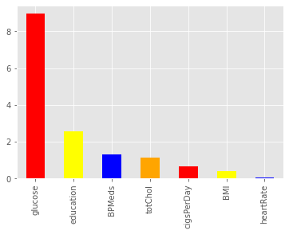

```python
round(df_copy[show_missing()].isnull().sum().sort_values(ascending = False)/len(df_copy)*100,2).plot(kind='bar', color=['red', 'yellow', 'blue', 'orange'])
```

**Glucose**

In the following column mean and median are nearby. we have fill the missing values so i am using median values for filling the missing values.

```python
df['glucose'].describe()
```

```
count    3086.000000
mean       82.086520
std        24.244753
min        40.000000
25%        71.000000
50%        78.000000
75%        87.000000
max       394.000000
Name: glucose, dtype: float64
```

```python
print('Glucose Feature Missing Before')
print(df_copy[['glucose']].isnull().sum())
print('--'*50)
df_copy['glucose']=df_copy['glucose'].fillna(df['glucose'].median())
print('Glucose Feature Missing After')
print(df_copy[['glucose']].isnull().sum())
print('--'*50)
```

```
Glucose Feature Missing Before
glucose    304
dtype: int64
----------------------------------------------------------------------------------------------------
Glucose Feature Missing After
glucose    0
dtype: int64
----------------------------------------------------------------------------------------------------
```

**Education**

```python
df['education'].describe()
```

```
count    3303.000000
mean        1.970936
std         1.019081
min         1.000000
25%         1.000000
50%         2.000000
75%         3.000000
max         4.000000
Name: education, dtype: float64
```

```python
df['education'].unique()
```

```
array([ 2.,  4.,  1.,  3., nan])
```

Education feature is not a continues variable so we using Mode for filling the missing values.

```python
print('Education Feature Missing Before')
print(df_copy[['education']].isnull().sum())
print('--'*50)
df_copy['education']=df_copy['education'].fillna(df['education'].mode()[0])
print('Education Feature Missing After')
print(df_copy[['education']].isnull().sum())
print('--'*50)
```

```
Education Feature Missing Before
education    87
dtype: int64
----------------------------------------------------------------------------------------------------
Education Feature Missing After
education    0
dtype: int64
----------------------------------------------------------------------------------------------------
```

**BPMeds**

```python
df['BPMeds'].describe()
```

```
count    3346.000000
mean        0.029886
std         0.170299
min         0.000000
25%         0.000000
50%         0.000000
75%         0.000000
max         1.000000
Name: BPMeds, dtype: float64
```

```python
df['BPMeds'].unique()
```

```
array([ 0., nan,  1.])
```

```python
print('BPMeds Feature Missing Before')
print(df_copy[['BPMeds']].isnull().sum())
print('--'*50)
df_copy['BPMeds']=df_copy['BPMeds'].fillna(df['BPMeds'].mode()[0])
print('BPMeds Feature Missing After')
print(df_copy[['BPMeds']].isnull().sum())
print('--'*50)
```

```
BPMeds Feature Missing Before
BPMeds    44
dtype: int64
----------------------------------------------------------------------------------------------------
BPMeds Feature Missing After
BPMeds    0
dtype: int64
----------------------------------------------------------------------------------------------------
```

Total Cholostral

```python
df['totChol'].describe()
```

```
count    3352.000000
mean      237.074284
std        45.247430
min       107.000000
25%       206.000000
50%       234.000000
75%       264.000000
max       696.000000
Name: totChol, dtype: float64
```

```python
print('Total colostrol Feature Missing Before')
print(df_copy[['totChol']].isnull().sum())
print('--'*50)
df_copy['totChol']=df_copy['totChol'].fillna(df['totChol'].median())
print('Total colostrol Feature Missing After')
print(df_copy[['totChol']].isnull().sum())
print('--'*50)
```

```
Total colostrol Feature Missing Before
totChol    38
dtype: int64
----------------------------------------------------------------------------------------------------
Total colostrol Feature Missing After
totChol    0
dtype: int64
----------------------------------------------------------------------------------------------------
```

**Cigrates per Day**

```python
df['cigsPerDay'].describe()
```

```
count    3368.000000
mean        9.069477
std        11.879078
min         0.000000
25%         0.000000
50%         0.000000
75%        20.000000
max        70.000000
Name: cigsPerDay, dtype: float64
```

```python
print('Cigars per day Feature Missing Before')
print(df_copy[['cigsPerDay']].isnull().sum())
print('--'*50)
df_copy['cigsPerDay']=df_copy['cigsPerDay'].fillna(df['cigsPerDay'].median())
print('Cigars per day Feature Missing After')
print(df_copy[['cigsPerDay']].isnull().sum())
print('--'*50)
```

```
Cigars per day Feature Missing Before
cigsPerDay    22
dtype: int64
----------------------------------------------------------------------------------------------------
Cigars per day Feature Missing After
cigsPerDay    0
dtype: int64
----------------------------------------------------------------------------------------------------
```

**Body Mass Index(BMI)**

```python
df['BMI'].describe()
```

```
count    3376.000000
mean       25.794964
std         4.115449
min        15.960000
25%        23.020000
50%        25.380000
75%        28.040000
max        56.800000
Name: BMI, dtype: float64
```

```python
print('BMI Feature Missing Before')
print(df_copy[['BMI']].isnull().sum())
print('--'*50)
df_copy['BMI']=df_copy['BMI'].fillna(df['BMI'].median())
print('BMI Feature Missing After')
print(df_copy[['BMI']].isnull().sum())
print('--'*50)
```

```
BMI Feature Missing Before
BMI    14
dtype: int64
----------------------------------------------------------------------------------------------------
BMI Feature Missing After
BMI    0
dtype: int64
----------------------------------------------------------------------------------------------------
```

Heart Rate

```python
df['heartRate'].describe()
```

```
count    3389.000000
mean       75.977279
std        11.971868
min        45.000000
25%        68.000000
50%        75.000000
75%        83.000000
max       143.000000
Name: heartRate, dtype: float64
```

```python
print('Heart Rate Feature Missing Before')
print(df_copy[['heartRate']].isnull().sum())
print('--'*50)
df_copy['heartRate']=df_copy['heartRate'].fillna(df['heartRate'].median())
print('Heart Rate Feature Missing After')
print(df_copy[['heartRate']].isnull().sum())
print('--'*50)
```

```
Heart Rate Feature Missing Before
heartRate    1
dtype: int64
----------------------------------------------------------------------------------------------------
Heart Rate Feature Missing After
heartRate    0
dtype: int64
----------------------------------------------------------------------------------------------------
```

# **EDA**

### **Age**

Data contains people of age from 32-70 years. People are effected to cardivasucular Desises from 35

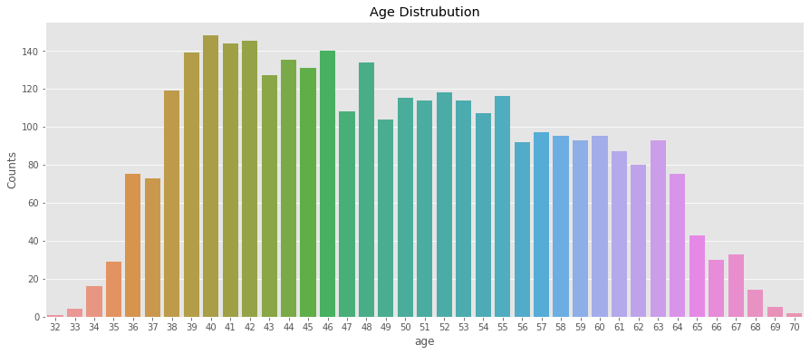

```python
fig, ax = plt.subplots(figsize=(15,6))
age_dis=pd.DataFrame(df.groupby(['age'])['id'].count())
sns.barplot(x=age_dis.index,y=age_dis['id'])
plt.ylabel('Counts')
plt.title('Age Distrubution')
```

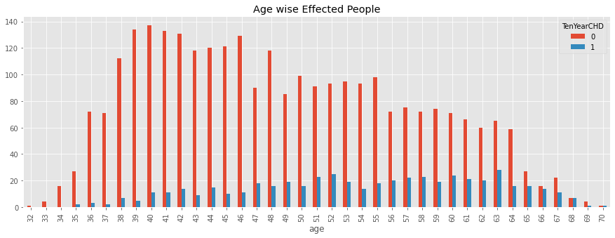

```python
plt.rcParams['figure.figsize'] = (15, 5)
df.groupby(['age','TenYearCHD'])['id'].count().unstack().plot(kind='bar')
plt.title('Age wise Effected People')
```

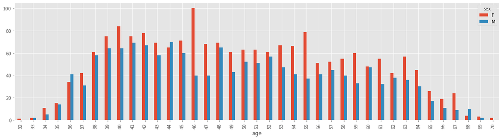

```python
plt.rcParams['figure.figsize'] = (20, 5)
df.groupby(['age','sex'])['TenYearCHD'].count().unstack().plot(kind='bar')
```

### **Education**

```python
df['education'].unique()
```

```
array([ 2.,  4.,  1.,  3., nan])
```

```python
df.groupby(['education'])['id'].count()
```

```
education
1.0    1391
2.0     990
3.0     549
4.0     373
Name: id, dtype: int64
```

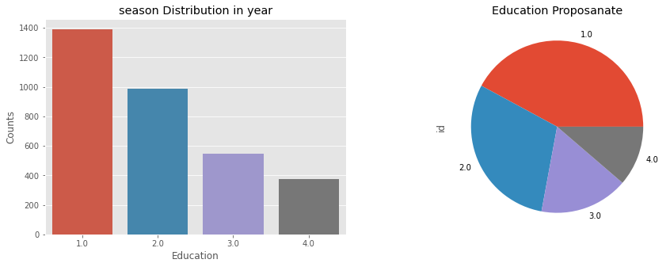

```python
fig, ax = plt.subplots(1,2,figsize=(15,5))
ax1=plt.subplot(1,2,1)
Education_status=pd.DataFrame(df.groupby(['education'])['id'].count())
sns.barplot(x=Education_status.index,y=Education_status['id'])
plt.xlabel('Education')
plt.ylabel('Counts')
plt.title('season Distribution in year')
ax2=plt.subplot(1,2,2)
df.groupby(['education'])['id'].count().plot(kind='pie')
plt.title('Education Proposanate')
```

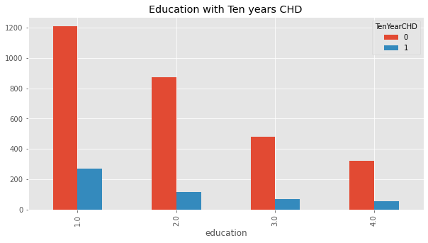

```python
plt.rcParams['figure.figsize'] = (10, 5)
df_copy.groupby(['education','TenYearCHD'])['id'].count().unstack().plot(kind='bar')
plt.title('Education with Ten years CHD')
```

### **SEX**

```python
df.groupby(['sex'])['id'].count()
```

```
sex
F    1923
M    1467
Name: id, dtype: int64
```

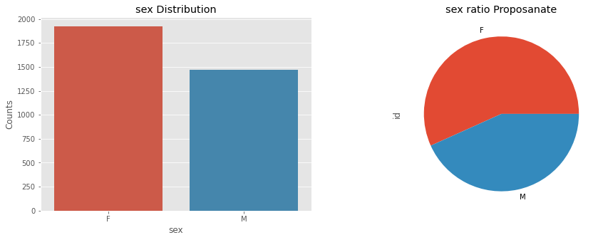

```python
fig, ax = plt.subplots(1,2,figsize=(15,5))
ax1=plt.subplot(1,2,1)
Education_status=pd.DataFrame(df.groupby(['sex'])['id'].count())
sns.barplot(x=Education_status.index,y=Education_status['id'])
plt.xlabel('sex')
plt.ylabel('Counts')
plt.title('sex Distribution')
ax2=plt.subplot(1,2,2)
df.groupby(['sex'])['id'].count().plot(kind='pie')
plt.title('sex ratio Proposanate')
```

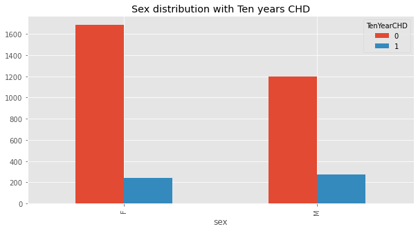

```python
plt.rcParams['figure.figsize'] = (10, 5)
df_copy.groupby(['sex','TenYearCHD'])['id'].count().unstack().plot(kind='bar')
plt.title('Sex distribution with Ten years CHD')
```

### **Smoking Data**

```python
df.groupby(['is_smoking'])['id'].count()
```

```
is_smoking
NO     1703
YES    1687
Name: id, dtype: int64
```

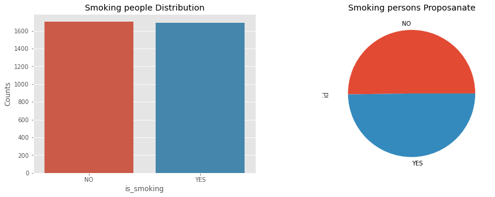

```python
fig, ax = plt.subplots(1,2,figsize=(15,5))
ax1=plt.subplot(1,2,1)
Education_status=pd.DataFrame(df.groupby(['is_smoking'])['id'].count())
sns.barplot(x=Education_status.index,y=Education_status['id'])
plt.xlabel('is_smoking')
plt.ylabel('Counts')
plt.title('Smoking people Distribution')
ax2=plt.subplot(1,2,2)
df.groupby(['is_smoking'])['id'].count().plot(kind='pie')
plt.title('Smoking persons Proposanate')
```

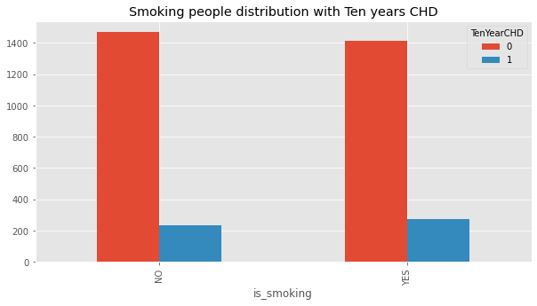

```python
plt.rcParams['figure.figsize'] = (10, 5)
df_copy.groupby(['is_smoking','TenYearCHD'])['id'].count().unstack().plot(kind='bar')
plt.title('Smoking people distribution with Ten years CHD')
```

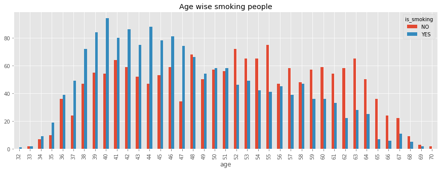

```python
plt.rcParams['figure.figsize'] = (15, 5)
df.groupby(['age','is_smoking'])['id'].count().unstack().plot(kind='bar')
plt.title('Age wise smoking people')
```

### **Cigretes per Day**

```python
df.groupby(['cigsPerDay'])['id'].count()
```

```
cigsPerDay
0.0     1703
1.0       48
2.0       17
3.0       79
4.0        7
5.0      103
6.0       14
7.0        8
8.0       10
9.0      104
10.0     106
11.0       4
12.0       3
13.0       3
14.0       1
15.0     172
16.0       2
17.0       5
18.0       7
19.0       2
20.0     606
23.0       5
25.0      44
30.0     176
35.0      17
38.0       1
40.0      62
43.0      42
45.0       2
50.0       6
60.0       8
70.0       1
Name: id, dtype: int64
```

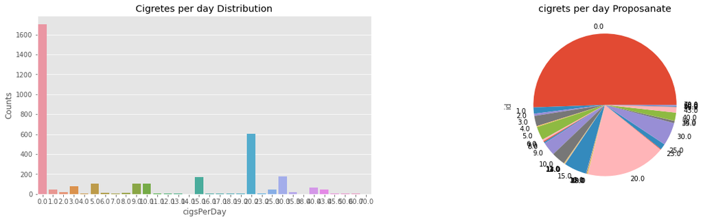

```python
fig, ax = plt.subplots(1,2,figsize=(20,5))
ax1=plt.subplot(1,2,1)
Education_status=pd.DataFrame(df.groupby(['cigsPerDay'])['id'].count())
sns.barplot(x=Education_status.index,y=Education_status['id'])
plt.xlabel('cigsPerDay')
plt.ylabel('Counts')
plt.title('Cigretes per day Distribution')
ax2=plt.subplot(1,2,2)
df.groupby(['cigsPerDay'])['id'].count().plot(kind='pie')
plt.title('cigrets per day Proposanate')
```

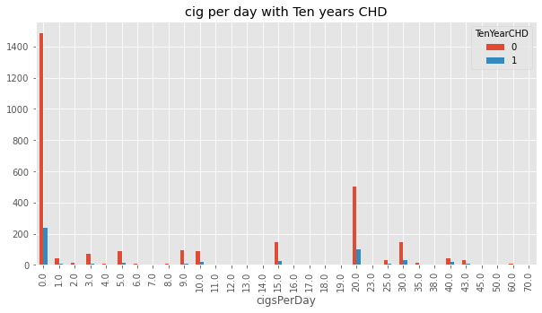

```python
plt.rcParams['figure.figsize'] = (10, 5)
df_copy.groupby(['cigsPerDay','TenYearCHD'])['id'].count().unstack().plot(kind='bar')
plt.title('cig per day with Ten years CHD')
```

### **BP Medication**

```python
df.groupby(['BPMeds'])['id'].count()
```

```
BPMeds
0.0    3246
1.0     100
Name: id, dtype: int64
```

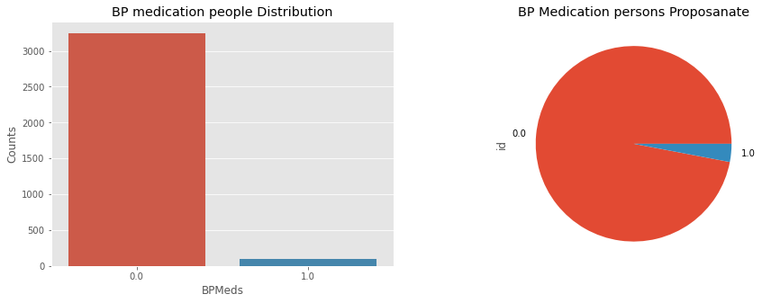

```python
fig, ax = plt.subplots(1,2,figsize=(15,5))
ax1=plt.subplot(1,2,1)
Education_status=pd.DataFrame(df.groupby(['BPMeds'])['id'].count())
sns.barplot(x=Education_status.index,y=Education_status['id'])
plt.xlabel('BPMeds')
plt.ylabel('Counts')
plt.title('BP medication people Distribution')
ax2=plt.subplot(1,2,2)
df.groupby(['BPMeds'])['id'].count().plot(kind='pie')
plt.title('BP Medication persons Proposanate')
```

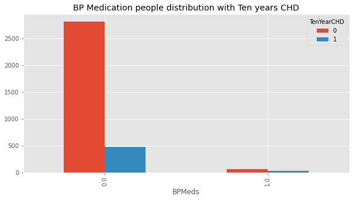

```python
plt.rcParams['figure.figsize'] = (10, 5)
df_copy.groupby(['BPMeds','TenYearCHD'])['id'].count().unstack().plot(kind='bar')
plt.title('BP Medication people distribution with Ten years CHD')
```

### **Prevalent Stroke**

```python
df.groupby(['prevalentStroke'])['id'].count()
```

```
prevalentStroke
0    3368
1      22
Name: id, dtype: int64
```

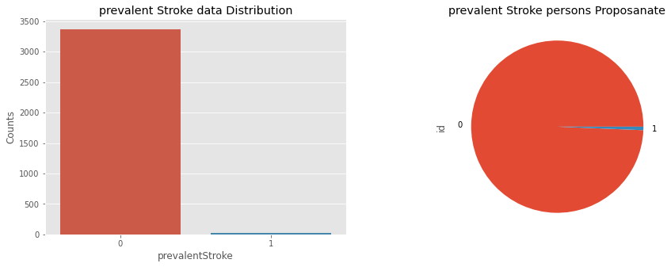

```python
fig, ax = plt.subplots(1,2,figsize=(15,5))
ax1=plt.subplot(1,2,1)
Education_status=pd.DataFrame(df.groupby(['prevalentStroke'])['id'].count())
sns.barplot(x=Education_status.index,y=Education_status['id'])
plt.xlabel('prevalentStroke')
plt.ylabel('Counts')
plt.title('prevalent Stroke data Distribution')
ax2=plt.subplot(1,2,2)
df.groupby(['prevalentStroke'])['id'].count().plot(kind='pie')
plt.title('prevalent Stroke persons Proposanate')
```

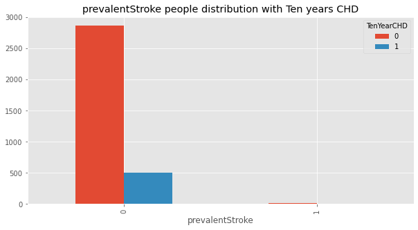

```python
plt.rcParams['figure.figsize'] = (10, 5)
df_copy.groupby(['prevalentStroke','TenYearCHD'])['id'].count().unstack().plot(kind='bar')
plt.title('prevalentStroke people distribution with Ten years CHD')
```

### **Hypertension**

```python
df.groupby(['prevalentHyp'])['id'].count()
```

```
prevalentHyp
0    2321
1    1069
Name: id, dtype: int64
```

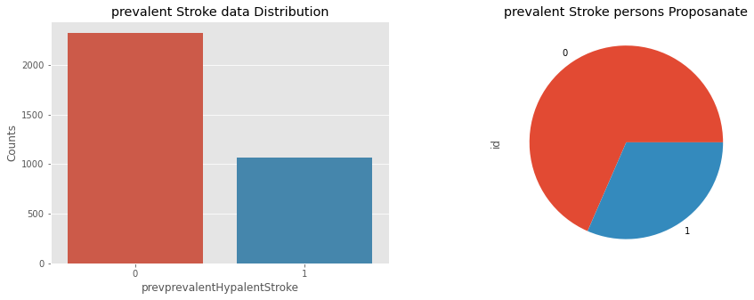

```python
fig, ax = plt.subplots(1,2,figsize=(15,5))
ax1=plt.subplot(1,2,1)
Education_status=pd.DataFrame(df.groupby(['prevalentHyp'])['id'].count())
sns.barplot(x=Education_status.index,y=Education_status['id'])
plt.xlabel('prevprevalentHypalentStroke')
plt.ylabel('Counts')
plt.title('prevalent Stroke data Distribution')
ax2=plt.subplot(1,2,2)
df.groupby(['prevalentHyp'])['id'].count().plot(kind='pie')
plt.title('prevalent Stroke persons Proposanate')
```

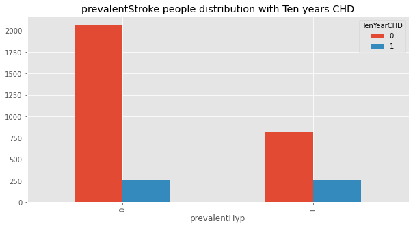

```python
plt.rcParams['figure.figsize'] = (10, 5)
df_copy.groupby(['prevalentHyp','TenYearCHD'])['id'].count().unstack().plot(kind='bar')
plt.title('prevalentStroke people distribution with Ten years CHD')
```

### **diabetes**

```python
df.groupby(['diabetes'])['id'].count()
```

```
diabetes
0    3303
1      87
Name: id, dtype: int64
```

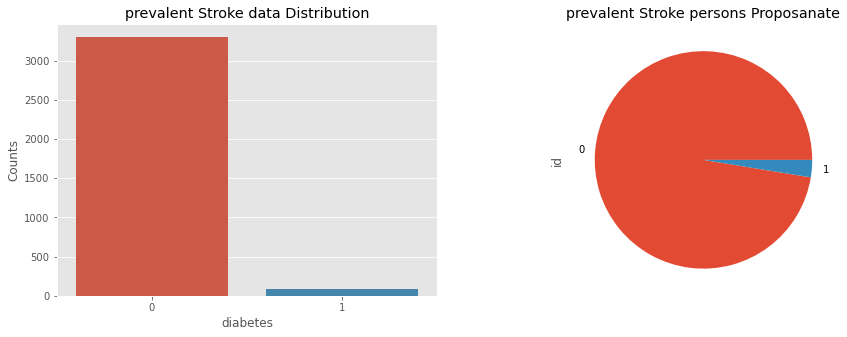

```python
fig, ax = plt.subplots(1,2,figsize=(15,5))
ax1=plt.subplot(1,2,1)
Education_status=pd.DataFrame(df.groupby(['diabetes'])['id'].count())
sns.barplot(x=Education_status.index,y=Education_status['id'])
plt.xlabel('diabetes')
plt.ylabel('Counts')
plt.title('prevalent Stroke data Distribution')
ax2=plt.subplot(1,2,2)
df.groupby(['diabetes'])['id'].count().plot(kind='pie')
plt.title('prevalent Stroke persons Proposanate')
```

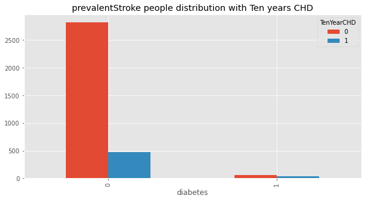

```python
plt.rcParams['figure.figsize'] = (10, 5)
df_copy.groupby(['diabetes','TenYearCHD'])['id'].count().unstack().plot(kind='bar')
plt.title('prevalentStroke people distribution with Ten years CHD')
```

### **totChol**

```python
df.groupby(['totChol'])['id'].count()
```

```
totChol
107.0    1
113.0    1
119.0    1
124.0    1
126.0    1
        ..
439.0    1
453.0    1
464.0    1
600.0    1
696.0    1
Name: id, Length: 240, dtype: int64
```

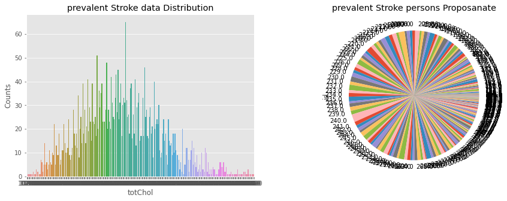

```python
fig, ax = plt.subplots(1,2,figsize=(15,5))
ax1=plt.subplot(1,2,1)
Education_status=pd.DataFrame(df.groupby(['totChol'])['id'].count())
sns.barplot(x=Education_status.index,y=Education_status['id'])
plt.xlabel('totChol')
plt.ylabel('Counts')
plt.title('prevalent Stroke data Distribution')
ax2=plt.subplot(1,2,2)
df.groupby(['totChol'])['id'].count().plot(kind='pie')
plt.title('prevalent Stroke persons Proposanate')
```

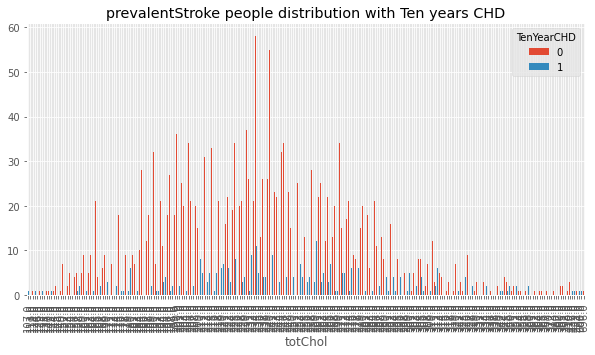

```python
plt.rcParams['figure.figsize'] = (10, 5)
df_copy.groupby(['totChol','TenYearCHD'])['id'].count().unstack().plot(kind='bar')
plt.title('prevalentStroke people distribution with Ten years CHD')
```

### **sysBP**

```python
df.groupby(['sysBP'])['id'].count()
```

```
sysBP
83.5     2
85.0     1
85.5     1
90.0     2
92.5     1
        ..
235.0    1
243.0    1
244.0    1
248.0    1
295.0    1
Name: id, Length: 226, dtype: int64
```

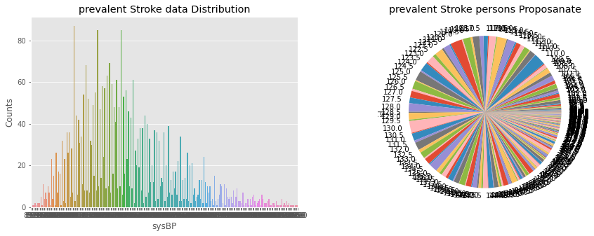

```python
fig, ax = plt.subplots(1,2,figsize=(15,5))
ax1=plt.subplot(1,2,1)
Education_status=pd.DataFrame(df.groupby(['sysBP'])['id'].count())
sns.barplot(x=Education_status.index,y=Education_status['id'])
plt.xlabel('sysBP')
plt.ylabel('Counts')
plt.title('prevalent Stroke data Distribution')
ax2=plt.subplot(1,2,2)
df.groupby(['sysBP'])['id'].count().plot(kind='pie')
plt.title('prevalent Stroke persons Proposanate')
```

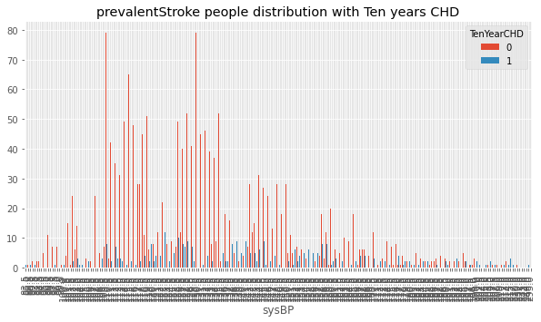

```python
plt.rcParams['figure.figsize'] = (10, 5)
df_copy.groupby(['sysBP','TenYearCHD'])['id'].count().unstack().plot(kind='bar')
plt.title('prevalentStroke people distribution with Ten years CHD')
```

### **diaBP**

```python
df.groupby(['diaBP'])['id'].count()
```

```
diaBP
48.0     1
50.0     1
51.0     1
52.0     2
53.0     1
        ..
130.0    5
133.0    2
135.0    2
136.0    2
142.5    1
Name: id, Length: 142, dtype: int64
```

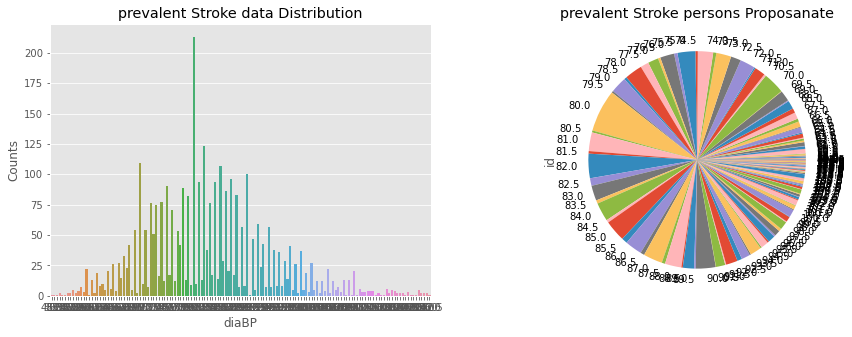

```python
fig, ax = plt.subplots(1,2,figsize=(15,5))
ax1=plt.subplot(1,2,1)
Education_status=pd.DataFrame(df.groupby(['diaBP'])['id'].count())
sns.barplot(x=Education_status.index,y=Education_status['id'])
plt.xlabel('diaBP')
plt.ylabel('Counts')
plt.title('prevalent Stroke data Distribution')
ax2=plt.subplot(1,2,2)
df.groupby(['diaBP'])['id'].count().plot(kind='pie')
plt.title('prevalent Stroke persons Proposanate')
```

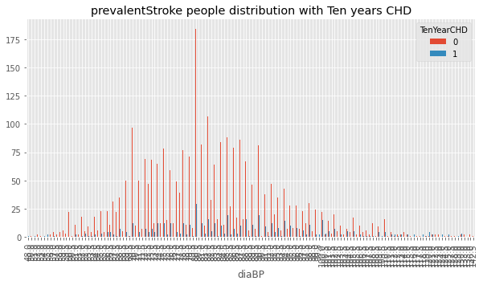

```python
plt.rcParams['figure.figsize'] = (10, 5)
df_copy.groupby(['diaBP','TenYearCHD'])['id'].count().unstack().plot(kind='bar')
plt.title('prevalentStroke people distribution with Ten years CHD')
```

### **BMI**

```python
df.groupby(['BMI'])['id'].count()
```

```
BMI
15.96    1
16.48    1
16.59    1
16.61    1
16.69    1
        ..
44.71    1
45.79    1
45.80    1
51.28    1
56.80    1
Name: id, Length: 1259, dtype: int64
```

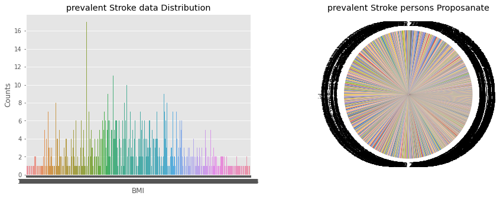

```python
fig, ax = plt.subplots(1,2,figsize=(15,5))
ax1=plt.subplot(1,2,1)
Education_status=pd.DataFrame(df.groupby(['BMI'])['id'].count())
sns.barplot(x=Education_status.index,y=Education_status['id'])
plt.xlabel('BMI')
plt.ylabel('Counts')
plt.title('prevalent Stroke data Distribution')
ax2=plt.subplot(1,2,2)
df.groupby(['BMI'])['id'].count().plot(kind='pie')
plt.title('prevalent Stroke persons Proposanate')
```

```python
plt.rcParams['figure.figsize'] = (10, 5)
df_copy.groupby(['BMI','TenYearCHD'])['id'].count().unstack().plot(kind='bar')
plt.title('prevalentStroke people distribution with Ten years CHD')
```

### **Heart Rate**

```python
df.groupby(['heartRate'])['id'].count()
```

```python
fig, ax = plt.subplots(1,2,figsize=(15,5))
ax1=plt.subplot(1,2,1)
Education_status=pd.DataFrame(df.groupby(['heartRate'])['id'].count())
sns.barplot(x=Education_status.index,y=Education_status['id'])
plt.xlabel('heartRate')
plt.ylabel('Counts')
plt.title('prevalent Stroke data Distribution')
ax2=plt.subplot(1,2,2)
df.groupby(['heartRate'])['id'].count().plot(kind='pie')
plt.title('prevalent Stroke persons Proposanate')
```

```python
plt.rcParams['figure.figsize'] = (10, 5)
df_copy.groupby(['heartRate','TenYearCHD'])['id'].count().unstack().plot(kind='bar')
plt.title('prevalentStroke people distribution with Ten years CHD')
```

### **Glucose**

```python
df.groupby(['glucose'])['id'].count()
```

```python
fig, ax = plt.subplots(1,2,figsize=(15,5))
ax1=plt.subplot(1,2,1)
Education_status=pd.DataFrame(df.groupby(['glucose'])['id'].count())
sns.barplot(x=Education_status.index,y=Education_status['id'])
plt.xlabel('prevalentStroke')
plt.ylabel('Counts')
plt.title('prevalent Stroke data Distribution')
ax2=plt.subplot(1,2,2)
df.groupby(['glucose'])['id'].count().plot(kind='pie')
plt.title('prevalent Stroke persons Proposanate')
```

```python
plt.rcParams['figure.figsize'] = (25, 5)
df_copy.groupby(['glucose','TenYearCHD'])['id'].count().unstack().plot(kind='bar')
plt.title('prevalentStroke people distribution with Ten years CHD')
```

```python
le=LabelEncoder()
df_copy['sex']=le.fit_transform(df_copy['sex'])
df_copy['is_smoking']=le.fit_transform(df_copy['is_smoking'])
```

```python
df_copy.head()
```

```python
df_copy.drop(['id'],axis=1,inplace=True) #Id is not useful for Model training.
```

```python
fig = plt.figure(figsize = (20,15))
ax = fig.gca()
df_copy.hist(ax = ax)
```

```python
plt.figure(figsize=(15,8))
correlation = df_copy.corr()
sns.heatmap(correlation, annot=True, cmap='coolwarm')
```

```python
for i in df_copy.columns[:-1]:
  fig = plt.figure(figsize=(9, 6))
  ax = fig.gca()
  df_copy.boxplot(column = i, by = 'TenYearCHD', ax = ax)
  ax.set_ylabel(i)
plt.show()
```

# **Classfication- Mechine Learning**

### Data Splitting

```python
X=df_copy[['age', 'education', 'sex', 'is_smoking', 'cigsPerDay', 'BPMeds',
       'prevalentStroke', 'prevalentHyp', 'diabetes', 'totChol', 'sysBP',
        'diaBP', 'BMI', 'heartRate', 'glucose']].copy()
y=df_copy['TenYearCHD'].copy()
```

```python
from sklearn.model_selection import train_test_split
X_train, X_test, y_train, y_test = train_test_split( X,y , test_size = 0.2, random_state = 0)
print(X_train.shape)
print(X_test.shape)
```

```python
y_train.value_counts()
```

```python
y_test.value_counts()
```

## **Logistic Regression**

```python
from sklearn.linear_model import LogisticRegression
clf = LogisticRegression(fit_intercept=True, max_iter=10000)
clf.fit(X_train, y_train)
```

```python
# Get the model coefficients
clf.coef_
```

```python
clf.intercept_
```

```python
# Get the predicted classes
train_class_preds = clf.predict(X_train)
test_class_preds = clf.predict(X_test)
```

```python
from sklearn.metrics import accuracy_score, confusion_matrix
import seaborn as sns
```

```python
# Get the accuracy scores
train_accuracy = accuracy_score(train_class_preds,y_train)
test_accuracy = accuracy_score(test_class_preds,y_test)

print("The accuracy on train data is ", train_accuracy)
print("The accuracy on test data is ", test_accuracy)
```

```python
# Get the confusion matrix for both train and test
plt.figure(figsize=(5,3))
labels = ['Negative', 'Positive']
cm = confusion_matrix(y_train, train_class_preds)
print(cm)

ax= plt.subplot()
sns.heatmap(cm, annot=True, ax = ax) #annot=True to annotate cells

# labels, title and ticks
ax.set_xlabel('Predicted labels')
ax.set_ylabel('True labels')
ax.set_title('Confusion Matrix')
ax.xaxis.set_ticklabels(labels)
ax.yaxis.set_ticklabels(labels)
```

```python
# Get the confusion matrix for both train and test
plt.figure(figsize=(5,3))
labels = ['Retained', 'Churned']
cm = confusion_matrix(y_test, test_class_preds)
print(cm)

ax= plt.subplot()
sns.heatmap(cm, annot=True, ax = ax); #annot=True to annotate cells

# labels, title and ticks
ax.set_xlabel('Predicted labels')
ax.set_ylabel('True labels')
ax.set_title('Confusion Matrix')
ax.xaxis.set_ticklabels(labels)
ax.yaxis.set_ticklabels(labels)
```

```python
y_lr_predict_pro=clf.predict_proba(X_test)[:,1]
```

```python
fpr, tpr, thresholds = roc_curve(y_test, y_lr_predict_pro)
```

```python
roc_auc_score(y_test,y_lr_predict_pro)
```

```python
plt.figure(figsize=(5,5))
plt.plot([0,1],[0,1],'k--')
plt.plot(fpr,tpr, label='Logistic Regression')
plt.xlabel('False Positive Rate')
plt.ylabel('True Positive Rate')
plt.title('Logistic Regression ROC curve')
plt.show()
```

## **Handling Data Imbalalance**

```python
from imblearn.over_sampling import SMOTE
smote = SMOTE(sampling_strategy='minority')
X_sm, y_sm = smote.fit_resample(X, y)
# X_sm, y_sm = smote.fit(X,y)
```

```python
y_sm=pd.DataFrame(y_sm)
```

```python
y_sm.value_counts()
```

## **Logistic Regression**

```python
X_train, X_test, y_train, y_test = train_test_split( X_sm,y_sm , test_size = 0.2, random_state = 0)
print(X_train.shape)
print(X_test.shape)
```

```python
y_train.value_counts()
```

```python
y_test.value_counts()
```

```python
clf = LogisticRegression(fit_intercept=True, max_iter=10000)
clf.fit(X_train, y_train)
```

```python
# Get the predicted classes
train_class_preds = clf.predict(X_train)
test_class_preds = clf.predict(X_test)
```

```python
# Get the accuracy scores
train_accuracy = accuracy_score(train_class_preds,y_train)
test_accuracy = accuracy_score(test_class_preds,y_test)

print("The accuracy on train data is ", train_accuracy)
print("The accuracy on test data is ", test_accuracy)
```

```python
# Get the confusion matrix for both train and test

cm = confusion_matrix(y_train, train_class_preds)
print('Confusion Matrix for training Data')
print(cm)
cm = confusion_matrix(y_test, test_class_preds)
print('Confusion Matrix for Test Data')
print(cm)
```

```python
y_lr_predict_pro=clf.predict_proba(X_test)[:,1]
fpr, tpr, thresholds = roc_curve(y_test, y_lr_predict_pro)
```

```python
roc_auc_score(y_test,y_lr_predict_pro)
```

```python
plt.figure(figsize=(5,5))
plt.plot([0,1],[0,1],'k--')
plt.plot(fpr,tpr, label='Logistic Regression')
plt.xlabel('False Positive Rate')
plt.ylabel('True Positive Rate')
plt.title('Logistic Regression ROC curve')
plt.show()
```

## **Decision Tree Classifier**

```python
dt_scores = []
for i in range(1, len(X.columns) + 1):
    dt_classifier = DecisionTreeClassifier(max_features = i, random_state = 0)
    dt_classifier.fit(X_train, y_train)
    dt_scores.append(round(dt_classifier.score(X_test, y_test),2))
```

```python
plt.plot([i for i in range(1, len(X.columns) + 1)], dt_scores, color = 'green')
for i in range(1, len(X.columns) + 1):
    plt.text(i, dt_scores[i-1], (i, dt_scores[i-1]))
plt.xticks([i for i in range(1, len(X.columns) + 1)])
plt.xlabel('Max features')
plt.ylabel('Scores')
plt.title('Decision Tree Classifier scores for different number of maximum features')
```

```python
y_dt_predict_pro=dt_classifier.predict_proba(X_test)[:,1]
fpr, tpr, thresholds = roc_curve(y_test, y_dt_predict_pro)
```

```python
roc_auc_score(y_test,y_dt_predict_pro)
```

```python
plt.figure(figsize=(5,5))
plt.plot([0,1],[0,1],'k--')
plt.plot(fpr,tpr, label='Decision Tree')
plt.xlabel('False Positive Rate')
plt.ylabel('True Positive Rate')
plt.title('Decision tree ROC curve')
plt.show()
```

```python
features = X.columns
importances = dt_classifier.feature_importances_
indices = np.argsort(importances)
```

```python
plt.figure(figsize=(12,9))
plt.title('Feature Importance')
plt.barh(range(len(indices)), importances[indices], color='red', align='center')
plt.yticks(range(len(indices)), [features[i] for i in indices])
plt.xlabel('Relative Importance')
plt.show()
```

## **Random Forest**

```python
classifier = RandomForestClassifier() # For GBM, use GradientBoostingClassifier()
grid_values = {'n_estimators':[50, 65, 80, 95,120], 'max_depth':[3, 5, 7,9,12]}
GSclassifier = GridSearchCV(classifier, param_grid = grid_values, scoring = 'roc_auc', cv=5)

# Fit the object to train dataset
GSclassifier.fit(X_train, y_train)
```

```python
bestvalues=GSclassifier.best_params_
GSclassifier.best_params_
```

```python
classifier = RandomForestClassifier(max_depth=bestvalues['max_depth'],n_estimators=bestvalues['n_estimators']) # For GBM, use GradientBoostingClassifier()

classifier.fit(X_train, y_train)
```

```python
y_train_preds_rf =  classifier.predict(X_train)
y_test_preds_rf= classifier.predict(X_test)
```

```python
# Obtain accuracy on train set
accuracy_score(y_train,y_train_preds_rf)
```

```python
# Obtain accuracy on test set
accuracy_score(y_test,y_test_preds_rf)
```

```python
y_rf_predict_pro=classifier.predict_proba(X_test)[:,1]
fpr, tpr, thresholds = roc_curve(y_test, y_rf_predict_pro)
```

```python
roc_auc_score(y_test,y_rf_predict_pro)
```

```python
plt.figure(figsize=(5,5))
plt.plot([0,1],[0,1],'k--')
plt.plot(fpr,tpr, label='Random Forest')
plt.xlabel('False Positive Rate')
plt.ylabel('True Positive Rate')
plt.title('Random Forest ROC curve')
plt.show()
```

```python
features = X.columns
importances = classifier.feature_importances_
indices = np.argsort(importances)
```

```python
plt.figure(figsize=(12,9))
plt.title('Feature Importance')
plt.barh(range(len(indices)), importances[indices], color='red', align='center')
plt.yticks(range(len(indices)), [features[i] for i in indices])
plt.xlabel('Relative Importance')
plt.show()
```

## **KNN**

```python
param_grid = {'n_neighbors':np.arange(1,50)}
```

```python
knn = KNeighborsClassifier()
knn_cv= GridSearchCV(knn,param_grid,cv=5)
knn_cv.fit(X_sm,y_sm)
```

```python
bestPermet=knn_cv.best_params_
knn_cv.best_params_
```

```python
#Setup arrays to store training and test accuracies
neighbors = np.arange(1,30)
train_accuracy =np.empty(len(neighbors))
test_accuracy = np.empty(len(neighbors))

for i,k in enumerate(neighbors):
    # Setup a knn classifier with k neighbors
    knn = KNeighborsClassifier(n_neighbors=k)

    # Fit the model
    knn.fit(X_train, y_train)

    # Compute accuracy on the training set
    train_accuracy[i] = knn.score(X_train, y_train)

    # Compute accuracy on the test set
    test_accuracy[i] = knn.score(X_test, y_test)
```

```python
plt.title('k-NN Varying number of neighbors')
plt.plot(neighbors, test_accuracy, label='Testing Accuracy')
plt.plot(neighbors, train_accuracy, label='Training accuracy')
plt.legend()
plt.xlabel('Number of neighbors')
plt.ylabel('Accuracy')
plt.show()
```

```python
# Setup a knn classifier with k neighbors
knn = KNeighborsClassifier(n_neighbors=bestPermet['n_neighbors'])
```

```python
# Fit the model
knn.fit(X_train,y_train)
```

```python
knn.score(X_test,y_test)
```

```python
y_test_pred_knn = knn.predict(X_test)
```

```python
confusion_matrix(y_test,y_test_pred_knn)
```

```python
y_pred_proba = knn.predict_proba(X_test)[:,1]
```

```python
fpr, tpr, thresholds = roc_curve(y_test, y_pred_proba)
```

```python
roc_auc_score(y_test,y_pred_proba)
```

```python
plt.figure(figsize=(5,5))
plt.plot([0,1],[0,1],'k--')
plt.plot(fpr,tpr, label='Knn')
plt.xlabel('False Positive Rate')
plt.ylabel('True Positive Rate')
plt.title('Knn(n_neighbors=2) ROC curve')
plt.show()
```

## **SVM**

```python
svc_scores = []
kernels = ['linear', 'poly', 'rbf', 'sigmoid']
for i in range(len(kernels)):
    svc_classifier = SVC(kernel = kernels[i])
    svc_classifier.fit(X_train, y_train)
    svc_scores.append(round(svc_classifier.score(X_test, y_test),2))
```

```python
# colors = rainbow(np.linspace(0, 1, len(kernels)))
plt.figure(figsize=(7,4))
plt.bar(kernels, svc_scores,color=['red', 'yellow', 'blue', 'orange'])
for i in range(len(kernels)):
    plt.text(i, svc_scores[i], svc_scores[i])
plt.xlabel('Kernels')
plt.ylabel('Scores')
plt.title('Support Vector Classifier scores for different kernels')
```

```python
svm=SVC(probability=True)
svm.fit(X_train,y_train)
```

```python
svm.score(X_test,y_test)
```

```python
y_svm_predi=svm.predict(X_test)
```

```python
confusion_matrix(y_test,y_svm_predi)
```

```python
y_svm_predict_pro=svm.predict_proba(X_test)[:,1]
fpr, tpr, thresholds = roc_curve(y_test, y_svm_predict_pro)
```

```python
roc_auc_score(y_test,y_svm_predict_pro)
```

```python
plt.figure(figsize=(5,5))
plt.plot([0,1],[0,1],'k--')
plt.plot(fpr,tpr, label='SVM')
plt.xlabel('False Positive Rate')
plt.ylabel('True Positive Rate')
plt.title('SVM ROC curve')
plt.show()
```

## **Cat Boost**

```python
!pip install catboost
```

```python
from catboost import CatBoostClassifier
```

```python
catboost=CatBoostClassifier(iterations=100,learning_rate=0.03)
```

```python
catboost.fit(X_train,y_train,verbose=10)
```

```python
y_catboost_pred=catboost.predict(X_test)
y_catboost_pre_prob=catboost.predict_proba(X_test)[:,1]
```

```python
catboost.score(X_test,y_test)
```

```python
confusion_matrix(y_test,y_catboost_pred)
```

```python
roc_auc_score(y_test,y_catboost_pre_prob)
```

```python
fpr, tpr, thresholds = roc_curve(y_test, y_catboost_pre_prob)
```

```python
plt.figure(figsize=(5,5))
plt.plot([0,1],[0,1],'k--')
plt.plot(fpr,tpr, label='Cat Boost')
plt.xlabel('False Positive Rate')
plt.ylabel('True Positive Rate')
plt.title('Cat Boost ROC curve')
plt.show()
```

## **Neural Networks**

```python
X_train=pd.DataFrame(X_train)
y_train = pd.DataFrame(y_train)
```

```python
# #since we shuffled, the index numbers were messed up, this resets them
X_train = X_train.reset_index(drop=True)
y_train = y_train.reset_index(drop=True)

#convert to numpy arrays with float values
X_train = np.array(X_train, dtype=float)
y_train = np.array(y_train, dtype=float)

#reshape y_train to make matrix multiplication possible
y_train = np.array(y_train).reshape(-1, 1)
```

```python
class Perceptron:
    def __init__(self, x, y):

        self.input = np.array(x, dtype=float)
        self.label = np.array(y, dtype=float)
        self.weights = np.random.rand(x.shape[1], y.shape[1]) #randomly initialize the weights
        self.z = self.input@self.weights #dot product of the vectors
        self.yhat = self.sigmoid(self.z) #apply activation function


    def sigmoid(self, x):
        return 1.0/(1.0+np.exp(-x))

    def sigmoid_deriv(self, x):
        s = sigmoid(x)
        return s(1-s)

    def forward_prop(self):
        self.yhat = self.sigmoid(self.input @ self.weights) #@ symbol represents matrix multiplication (also works for vectors)
        return self.yhat

    def back_prop(self):
        gradient = self.input.T @ (-2.0*(self.label - self.yhat)*self.sigmoid(self.yhat))  #self.input is the x value

        self.weights -= gradient #process of finding the minimum loss
```

```python
simple_nn = Perceptron(X_train, y_train)
training_iterations = 1000

history = [] #we will store how the mean squared error changes after each iteration in this array

def mse(yhat, y):
    sum = 0.0
    for pred, label in zip(yhat, y):
        sum += (pred-label)**2
    return sum/len(yhat)

for i in range(training_iterations):
    simple_nn.forward_prop()
    simple_nn.back_prop()
    yhat = simple_nn.forward_prop()
    history.append(mse(yhat, simple_nn.label))



yhat = simple_nn.forward_prop()
print(f'Final Mean Squared Error: {mse(yhat, simple_nn.label)}')
```

```python
plt.plot(history)
plt.ylabel('Mean Squared Error')
plt.xlabel('Training Iteration')
```